# Ejercicios Estructura de Datos

Andrea Catalina Mora Roa

# 1 Ejercicio 1

## 1.1 Microdatos GEIH del DANE en formato CSV

**Clasificación:** estructurada.

El formato CSV representa una tabla: cada fila corresponde normalmente a una observación y cada columna a una variable. Que el archivo tenga 300.000 filas afecta el costo computacional de la lectura, pero no cambia su clasificación.

El preprocesamiento mínimo consiste en importar el archivo con el delimitador y la codificación correctos, revisar los tipos de las variables y reconocer los códigos usados para valores ausentes. Los identificadores y las variables categóricas codificadas no deberían convertirse automáticamente en números continuos.

```r
library(readr)
library(janitor)
library(dplyr)

geih <- read_csv(
  "microdatos_geih.csv",
  na = c("", "NA", "N/A")
) |>
  clean_names() |>
  as_tibble()

glimpse(geih)
```

## 1.2 Respuesta JSON de la API pública datos.gov.co

**Clasificación:** semiestructurada.

Una respuesta JSON contiene una organización interna basada en objetos, arreglos y pares clave-valor. Sin embargo, algunos campos pueden contener otros objetos o listas, por lo que la respuesta no siempre es rectangular. La existencia de metadatos y registros en distintos niveles es otra razón para no clasificarla directamente como estructurada.

El mínimo requerido es leer la respuesta, ubicar el arreglo que contiene los registros y aplanar los campos anidados. Además, conviene convertir fechas y mediciones de calidad del aire a sus tipos adecuados.

```r
library(jsonlite)
library(tibble)
library(dplyr)

respuesta <- fromJSON(
  "URL_DE_LA_API",
  flatten = TRUE
)

# Si la API devuelve directamente un arreglo de registros:
calidad_aire <- as_tibble(respuesta) |>
  mutate(
    fecha = as.POSIXct(fecha, tz = "America/Bogota"),
    valor = as.numeric(valor)
  )
```

## 1.3 Grabaciones de audio de audiencias judiciales

**Clasificación:** no estructurada.

Una grabación almacena una señal sonora. Aunque el archivo tenga metadatos —por ejemplo, duración o fecha—, el contenido de la audiencia no está organizado en variables y registros. Por ello, no puede transformarse en un `tibble` solo mediante una función de importación tabular.

El preprocesamiento mínimo consiste en transcribir el audio y convertir la transcripción en unidades observables. Para un análisis básico, cada fila puede representar una intervención y contener el archivo o audiencia, el hablante, el tiempo inicial, el tiempo final y el texto. Si se requiere distinguir a los participantes, también debe realizarse diarización de hablantes.

```r
library(tibble)

# Resultado ilustrativo después de la transcripción y la diarización
audiencia <- tibble(
  audiencia_id = c("A001", "A001"),
  hablante = c("Juez", "Interviniente 1"),
  inicio_seg = c(0.0, 12.4),
  fin_seg = c(12.3, 27.8),
  texto = c(
    "Se abre la audiencia...",
    "Gracias, señor juez..."
  )
)
```

La transcripción debe manejarse bajo las reglas aplicables de reserva, confidencialidad y protección de datos personales. Esta condición no modifica la clasificación, pero sí el procedimiento de tratamiento de la información.

## 1.4 Factura electrónica de la DIAN en formato XML

**Clasificación:** semiestructurada.

XML organiza la información mediante etiquetas, atributos y nodos anidados. La factura posee una jerarquía reconocible —emisor, adquirente, impuestos, totales e ítems—, pero esa jerarquía no es una tabla plana. Además, una factura puede tener múltiples líneas de detalle, lo que implica una relación de uno a muchos.

El preprocesamiento mínimo consiste en parsear el documento y extraer los nodos y atributos necesarios. Para evitar duplicaciones, es recomendable producir al menos dos `tibble`: uno para el encabezado de la factura y otro para sus líneas de detalle, unidos mediante un identificador.

```r
library(xml2)
library(purrr)
library(tibble)

doc <- read_xml("factura_electronica.xml")

# local-name() permite seleccionar nodos aun cuando el XML use namespaces.
lineas <- xml_find_all(doc, ".//*[local-name()='InvoiceLine']")

detalle <- map_dfr(lineas, function(nodo) {
  tibble(
    id_linea = xml_text(
      xml_find_first(nodo, ".//*[local-name()='ID']")
    ),
    cantidad = as.numeric(xml_text(
      xml_find_first(nodo, ".//*[local-name()='InvoicedQuantity']")
    )),
    descripcion = xml_text(
      xml_find_first(nodo, ".//*[local-name()='Description']")
    )
  )
})
```

## 1.5 Tabla HTML de Wikipedia extraída con `rvest`

**Clasificación:** estructurada dentro de una fuente semiestructurada.

El documento HTML completo es semiestructurado porque utiliza etiquetas y una jerarquía de elementos. No obstante, una tabla HTML seleccionada ya tiene filas y columnas, por lo que el objeto específico que se analizará puede considerarse estructurado. Esta distinción evita confundir la clasificación del documento contenedor con la de la tabla extraída.

El preprocesamiento mínimo consiste en leer la página, seleccionar la tabla correcta, convertirla a `tibble`, normalizar los nombres y ajustar los tipos de las columnas. También puede ser necesario retirar notas al pie o símbolos incluidos en las celdas.

```r
library(rvest)
library(janitor)
library(dplyr)
library(readr)

pagina <- read_html("URL_DE_WIKIPEDIA")

tabla_wikipedia <- pagina |>
  html_element("table.wikitable") |>
  html_table(fill = TRUE) |>
  as_tibble() |>
  clean_names() |>
  mutate(across(where(is.character), ~ trimws(.x)))

# Ejemplo si una columna numérica contiene símbolos o notas:
# tabla_wikipedia <- tabla_wikipedia |>
#   mutate(valor = parse_number(valor))
```

# 2 Ejercicio 2

```r
library(jsonlite)
library(dplyr)
library(tibble)
library(knitr)
```

```r
url <- "https://jsonplaceholder.typicode.com/users"
raw <- fromJSON(url)

dim(raw)
```

```
#> [1] 10  8
```

```r
class(raw)
```

```
#> [1] "data.frame"
```

## 2.1 Exploración de la estructura

Resultado de `str(raw)`

```r
str(raw)
```

```
#> 'data.frame':    10 obs. of  8 variables:
#>  $ id      : int  1 2 3 4 5 6 7 8 9 10
#>  $ name    : chr  "Leanne Graham" "Ervin Howell" "Clementine Bauch" "Patricia Lebsack" ...
#>  $ username: chr  "Bret" "Antonette" "Samantha" "Karianne" ...
#>  $ email   : chr  "Sincere@april.biz" "Shanna@melissa.tv" "Nathan@yesenia.net" "Julianne.OConner@kory.org" ...
#>  $ address :'data.frame':    10 obs. of  5 variables:
#>   ..$ street : chr  "Kulas Light" "Victor Plains" "Douglas Extension" "Hoeger Mall" ...
#>   ..$ suite  : chr  "Apt. 556" "Suite 879" "Suite 847" "Apt. 692" ...
#>   ..$ city   : chr  "Gwenborough" "Wisokyburgh" "McKenziehaven" "South Elvis" ...
#>   ..$ zipcode: chr  "92998-3874" "90566-7771" "59590-4157" "53919-4257" ...
#>   ..$ geo    :'data.frame':  10 obs. of  2 variables:
#>   .. ..$ lat: chr  "-37.3159" "-43.9509" "-68.6102" "29.4572" ...
#>   .. ..$ lng: chr  "81.1496" "-34.4618" "-47.0653" "-164.2990" ...
#>  $ phone   : chr  "1-770-736-8031 x56442" "010-692-6593 x09125" "1-463-123-4447" "493-170-9623 x156" ...
#>  $ website : chr  "hildegard.org" "anastasia.net" "ramiro.info" "kale.biz" ...
#>  $ company :'data.frame':    10 obs. of  3 variables:
#>   ..$ name       : chr  "Romaguera-Crona" "Deckow-Crist" "Romaguera-Jacobson" "Robel-Corkery" ...
#>   ..$ catchPhrase: chr  "Multi-layered client-server neural-net" "Proactive didactic contingency" "Face to face bifurcated interface" "Multi-tiered zero tolerance productivity" ...
#>   ..$ bs         : chr  "harness real-time e-markets" "synergize scalable supply-chains" "e-enable strategic applications" "transition cutting-edge web services" ...
```

Para reconocer con mayor claridad cada nivel se consultan los nombres de los componentes principales y anidados.

```r
names(raw)
```

```
#> [1] "id"       "name"     "username" "email"    "address"  "phone"    "website"
#> [8] "company"
```

```r
names(raw$address)
```

```
#> [1] "street"  "suite"   "city"    "zipcode" "geo"
```

```r
names(raw$address$geo)
```

```
#> [1] "lat" "lng"
```

```r
names(raw$company)
```

```
#> [1] "name"        "catchPhrase" "bs"
```

**Respuesta 1.** Las columnas anidadas del nivel principal son `address` y `company`. Dentro de `address` se encuentra un segundo objeto anidado, `geo`, que contiene `lat` y `lng`. `jsonlite` simplifica estas estructuras como columnas que son a su vez objetos `data.frame`; dado que un `data.frame` también es una lista, pueden describirse como columnas de estructura anidada.

## 2.2 Aplanamiento a un `tibble`

`jsonlite::flatten()` expande recursivamente los `data.frame` anidados. Los nombres de las variables resultantes reflejan la ruta jerárquica mediante puntos; por ejemplo, `address.geo.lat`.

```r
usuarios <- raw |>
  jsonlite::flatten(recursive = TRUE) |>
  as_tibble() |>
  transmute(
    name,
    email,
    address.city,
    address.geo.lat = as.numeric(address.geo.lat),
    address.geo.lng = as.numeric(address.geo.lng),
    company.name
  )

usuarios
```

| name | email | address.city | address.geo.lat | address.geo.lng | company.name |
| --- | --- | --- | --- | --- | --- |
| Leanne Graham | Sincere@april.biz | Gwenborough | -37.3159 | 81.1496 | Romaguera-Crona |
| Ervin Howell | Shanna@melissa.tv | Wisokyburgh | -43.9509 | -34.4618 | Deckow-Crist |
| Clementine Bauch | Nathan@yesenia.net | McKenziehaven | -68.6102 | -47.0653 | Romaguera-Jacobson |
| Patricia Lebsack | Julianne.OConner@kory.org | South Elvis | 29.4572 | -164.2990 | Robel-Corkery |
| Chelsey Dietrich | Lucio_Hettinger@annie.ca | Roscoeview | -31.8129 | 62.5342 | Keebler LLC |
| Mrs. Dennis Schulist | Karley_Dach@jasper.info | South Christy | -71.4197 | 71.7478 | Considine-Lockman |
| Kurtis Weissnat | Telly.Hoeger@billy.biz | Howemouth | 24.8918 | 21.8984 | Johns Group |
| Nicholas Runolfsdottir V | Sherwood@rosamond.me | Aliyaview | -14.3990 | -120.7677 | Abernathy Group |
| Glenna Reichert | Chaim_McDermott@dana.io | Bartholomebury | 24.6463 | -168.8889 | Yost and Sons |
| Clementina DuBuque | Rey.Padberg@karina.biz | Lebsackbury | -38.2386 | 57.2232 | Hoeger LLC |

**Decisión de preparación.** En la respuesta JSON, las coordenadas `lat` y `lng` están entre comillas y se importan inicialmente como texto. Se convierten a tipo numérico para permitir cálculos, filtros y visualizaciones.

### 2.2.1 Estructura del resultado

```r
glimpse(usuarios)
```

```
#> Rows: 10
#> Columns: 6
#> $ name            <chr> "Leanne Graham", "Ervin Howell", "Clementine Bauch", "…
#> $ email           <chr> "Sincere@april.biz", "Shanna@melissa.tv", "Nathan@yese…
#> $ address.city    <chr> "Gwenborough", "Wisokyburgh", "McKenziehaven", "South …
#> $ address.geo.lat <dbl> -37.3159, -43.9509, -68.6102, 29.4572, -31.8129, -71.4…
#> $ address.geo.lng <dbl> 81.1496, -34.4618, -47.0653, -164.2990, 62.5342, 71.74…
#> $ company.name    <chr> "Romaguera-Crona", "Deckow-Crist", "Romaguera-Jacobson…
```

### 2.2.2 Tabla final

```r
kable(
  usuarios,
  digits = 4,
  align = c("l", "l", "l", "r", "r", "l"),
  caption = "Tibble final con una fila por usuario y las variables solicitadas"
)
```

Tibble final con una fila por usuario y las variables solicitadas

| name | email | address.city | address.geo.lat | address.geo.lng | company.name |
| --- | --- | --- | --- | --- | --- |
| Leanne Graham | Sincere@april.biz | Gwenborough | -37.3159 | 81.1496 | Romaguera-Crona |
| Ervin Howell | Shanna@melissa.tv | Wisokyburgh | -43.9509 | -34.4618 | Deckow-Crist |
| Clementine Bauch | Nathan@yesenia.net | McKenziehaven | -68.6102 | -47.0653 | Romaguera-Jacobson |
| Patricia Lebsack | Julianne.OConner@kory.org | South Elvis | 29.4572 | -164.2990 | Robel-Corkery |
| Chelsey Dietrich | Lucio_Hettinger@annie.ca | Roscoeview | -31.8129 | 62.5342 | Keebler LLC |
| Mrs. Dennis Schulist | Karley_Dach@jasper.info | South Christy | -71.4197 | 71.7478 | Considine-Lockman |
| Kurtis Weissnat | Telly.Hoeger@billy.biz | Howemouth | 24.8918 | 21.8984 | Johns Group |
| Nicholas Runolfsdottir V | Sherwood@rosamond.me | Aliyaview | -14.3990 | -120.7677 | Abernathy Group |
| Glenna Reichert | Chaim_McDermott@dana.io | Bartholomebury | 24.6463 | -168.8889 | Yost and Sons |
| Clementina DuBuque | Rey.Padberg@karina.biz | Lebsackbury | -38.2386 | 57.2232 | Hoeger LLC |

**Respuesta 2.** El resultado contiene 10 filas y 6 columnas. Cada fila representa un usuario y se conservaron exactamente las variables solicitadas: `name`, `email`, `address.city`, `address.geo.lat`, `address.geo.lng` y `company.name`.

## 2.3 Tipo de fuente y explicación

**Respuesta 3.** La fuente es **semiestructurada**. JSON organiza la información mediante objetos, arreglos y pares clave–valor, pero permite jerarquías y campos anidados que no corresponden automáticamente a una tabla rectangular.

`fromJSON()` no produce directamente un `tibble` plano por dos razones:

1. **Conserva la jerarquía.** Al simplificar el arreglo de usuarios, mantiene `address` y `company` como `data.frame` anidados, y conserva `geo` dentro de `address`.
2. **Devuelve clases de base R.** Cuando puede simplificar un arreglo de objetos homogéneos, `jsonlite` devuelve un `data.frame`, no un `tibble`. La conversión a `tibble` debe hacerse mediante `as_tibble()`.

Por tanto, se requieren dos operaciones diferentes: **aplanar** la jerarquía y **convertir** la clase del objeto.

# 3 Ejercicio 3

```r
library(readr)
library(dplyr)
library(tidyr)
library(tibble)
library(Matrix)
library(knitr)
```

## 3.1 Eliminación de valores ausentes

Solo se eliminan las filas que tienen al menos un valor ausente en las cuatro variables requeridas. Los valores faltantes de otras columnas no afectan la matriz de diseño.

```r
datos_modelo <- titanic |>
  select(all_of(variables)) |>
  mutate(across(everything(), as.numeric)) |>
  drop_na()

resumen_filas <- tibble(
  concepto = c(
    "Filas originales",
    "Filas completas utilizadas",
    "Filas eliminadas por NA"
  ),
  cantidad = c(
    nrow(titanic),
    nrow(datos_modelo),
    nrow(titanic) - nrow(datos_modelo)
  )
)

kable(resumen_filas, align = c("l", "r"))
```

| concepto | cantidad |
| --- | --- |
| Filas originales | 891 |
| Filas completas utilizadas | 714 |
| Filas eliminadas por NA | 177 |

## 3.2 Matriz de diseño centrada y escalada

La función `scale()` resta a cada observación la media de su variable y divide el resultado por la desviación estándar muestral.

```r
X <- datos_modelo |>
  as.matrix() |>
  scale(center = TRUE, scale = TRUE)
```

### 3.2.1 Dimensiones y memoria

```r
memoria_X_bytes <- as.numeric(object.size(X))
memoria_X_legible <- format(object.size(X), units = "auto")

resumen_X <- tibble(
  medida = c("Número de filas", "Número de columnas", "Memoria"),
  resultado = c(
    format(nrow(X), big.mark = ".", scientific = FALSE),
    as.character(ncol(X)),
    memoria_X_legible
  )
)

kable(resumen_X, align = c("l", "r"))
```

| medida | resultado |
| --- | --- |
| Número de filas | 714 |
| Número de columnas | 4 |
| Memoria | 24.2 Kb |

**Respuesta 1.** La matriz estandarizada tiene 714 filas y 4 columnas. Ocupa 24.2 Kb según `object.size()`. Cada fila corresponde a un pasajero con información completa en las cuatro variables y cada columna corresponde a `age`, `fare`, `sibsp` o `parch`.

## 3.3 Cálculo de $X^{\mathsf{T}}X$

`crossprod(X)` calcula eficientemente el producto cruzado $X^{\mathsf{T}}X$ sin transponer explícitamente la matriz.

```r
XtX <- crossprod(X)

round(XtX, 4)
```

```
#>             age     fare     sibsp     parch
#> age    713.0000  68.4956 -219.7799 -134.8420
#> fare    68.4956 713.0000   98.6284  146.2498
#> sibsp -219.7799  98.6284  713.0000  273.6636
#> parch -134.8420 146.2498  273.6636  713.0000
```

### 3.3.1 Interpretación de la diagonal

```r
diagonal_XtX <- diag(XtX)
valor_teorico <- nrow(X) - 1

tabla_diagonal <- tibble(
  variable = names(diagonal_XtX),
  diagonal = as.numeric(diagonal_XtX),
  valor_teorico = valor_teorico,
  diferencia = as.numeric(diagonal_XtX) - valor_teorico
)

kable(tabla_diagonal, digits = 10, align = c("l", "r", "r", "r"))
```

| variable | diagonal | valor_teorico | diferencia |
| --- | --- | --- | --- |
| age | 713 | 713 | 0 |
| fare | 713 | 713 | 0 |
| sibsp | 713 | 713 | 0 |
| parch | 713 | 713 | 0 |

```r
all.equal(
  as.numeric(diagonal_XtX),
  rep(valor_teorico, ncol(X)),
  tolerance = 1e-10
)
```

```
#> [1] TRUE
```

**Respuesta 2.** Cada elemento diagonal de $X^{\mathsf{T}}X$ es la suma de cuadrados de una columna estandarizada:

$$(X^{\mathsf{T}}X)_{jj}=\sum_{i=1}^{n}x_{ij}^{2}.$$

Como `scale()` utiliza la desviación estándar muestral, calculada con denominador $n-1$, la diagonal es aproximadamente igual a $n-1$. En este caso, su valor teórico es 713. Los elementos fuera de la diagonal son $(n-1)$ veces las correlaciones muestrales entre las variables.

## 3.4 Representación dispersa

```r
X_sparse <- Matrix(X, sparse = TRUE)

memoria_sparse_bytes <- as.numeric(object.size(X_sparse))
memoria_sparse_legible <- format(object.size(X_sparse), units = "auto")
no_ceros <- Matrix::nnzero(X_sparse)
total_celdas <- length(X)
porcentaje_no_ceros <- 100 * no_ceros / total_celdas
porcentaje_ceros <- 100 - porcentaje_no_ceros

comparacion_memoria <- tibble(
  representacion = c("Matriz densa X", "Matriz dispersa X_sparse"),
  clase = c(class(X)[1], class(X_sparse)[1]),
  memoria = c(memoria_X_legible, memoria_sparse_legible),
  bytes = c(memoria_X_bytes, memoria_sparse_bytes)
)

kable(
  comparacion_memoria,
  format.args = list(big.mark = "."),
  align = c("l", "l", "r", "r")
)
```

| representacion | clase | memoria | bytes |
| --- | --- | --- | --- |
| Matriz densa X | matrix | 24.2 Kb | 24.760 |
| Matriz dispersa X_sparse | dgCMatrix | 35.3 Kb | 36.104 |

### 3.4.1 Densidad de la matriz

```r
resumen_densidad <- tibble(
  medida = c(
    "Celdas totales",
    "Valores distintos de cero",
    "Porcentaje distinto de cero",
    "Porcentaje de ceros"
  ),
  resultado = c(
    format(total_celdas, big.mark = "."),
    format(no_ceros, big.mark = "."),
    paste0(round(porcentaje_no_ceros, 2), "%"),
    paste0(round(porcentaje_ceros, 2), "%")
  )
)

kable(resumen_densidad, align = c("l", "r"))
```

| medida | resultado |
| --- | --- |
| Celdas totales | 2.856 |
| Valores distintos de cero | 2.856 |
| Porcentaje distinto de cero | 100% |
| Porcentaje de ceros | 0% |

**Respuesta 3.** La matriz densa ocupa 24.2 Kb y la matriz dispersa ocupa 35.3 Kb. El porcentaje de ceros es 0%. La representación dispersa no reduce la memoria en esta ejecución. Como la matriz tiene pocas columnas y la estandarización convierte la mayoría de las celdas en valores distintos de cero, el formato denso es más apropiado.

La representación dispersa es especialmente útil cuando una matriz grande contiene una proporción muy alta de ceros. En este ejercicio, centrar las variables suele destruir muchos ceros originales: un valor cero se transforma en $(0-\bar{x})/s$, que generalmente es distinto de cero. Por ello no debe suponerse que `sibsp` y `parch` continuarán siendo columnas dispersas después de aplicar `scale()`.

## 3.5 Estructura para modelar relaciones familiares

**Respuesta 4.** Para representar relaciones familiares entre pasajeros se utilizaría un **grafo** o red. Cada pasajero sería un nodo y cada vínculo familiar sería una arista. La arista podría incluir un atributo que identifique el tipo de relación, por ejemplo, cónyuge, hermano, padre, madre o hijo. Esta estructura permite estudiar componentes familiares, tamaños de grupos, grados de conexión y propagación de características dentro de una familia.

# 4 Ejercicio 4

## 4.1 Parámetros

```r
set.seed(42)

p_valores <- c(1, 2, 5, 10, 50, 100, 500, 1000, 5000)
n_puntos <- 500
n_pares <- 200

tibble(
  parametro = c("Dimensiones evaluadas", "Puntos por dimensión", "Pares por dimensión"),
  valor = c(
    paste(p_valores, collapse = ", "),
    n_puntos,
    n_pares
  )
) |>
  kable(align = c("l", "l"))
```

| parametro | valor |
| --- | --- |
| Dimensiones evaluadas | 1, 2, 5, 10, 50, 100, 500, 1000, 5000 |
| Puntos por dimensión | 500 |
| Pares por dimensión | 200 |

## 4.2 Funciones de cálculo

El coeficiente de variación se define como

$$CV=\frac{s}{\bar d},$$

donde $s$ es la desviación estándar de las distancias y $\bar d$ es su media. Cuando la media es numéricamente igual a cero, el CV no está definido y se reporta como `NA`.

```r
cv_seguro <- function(x, tolerancia = sqrt(.Machine$double.eps)) {
  media <- mean(x)

  if (!is.finite(media) || abs(media) < tolerancia) {
    return(NA_real_)
  }

  sd(x) / media
}

simular_dimension <- function(p, n = 500, m = 200) {
  # 500 puntos uniformes en [0, 1]^p
  puntos <- matrix(runif(n * p), nrow = n, ncol = p)

  # Cada columna contiene dos índices distintos. Los pares pueden repetirse
  # entre extracciones, pero un punto nunca se compara consigo mismo.
  pares <- replicate(m, sample.int(n, size = 2, replace = FALSE))

  A <- puntos[pares[1, ], , drop = FALSE]
  B <- puntos[pares[2, ], , drop = FALSE]

  # Distancia euclidiana
  distancia_euclidiana <- sqrt(rowSums((A - B)^2))

  # Distancia coseno = 1 - similitud coseno
  norma_A <- sqrt(rowSums(A^2))
  norma_B <- sqrt(rowSums(B^2))

  if (any(norma_A == 0 | norma_B == 0)) {
    stop("Se encontró un vector de norma cero; no puede calcularse el coseno.")
  }

  similitud_coseno <- rowSums(A * B) / (norma_A * norma_B)

  # Se corrigen únicamente desviaciones de redondeo fuera de [-1, 1].
  similitud_coseno <- pmin(1, pmax(-1, similitud_coseno))
  distancia_coseno <- pmax(0, 1 - similitud_coseno)

  tibble(
    p = p,
    par = seq_len(m),
    distancia_euclidiana = distancia_euclidiana,
    distancia_coseno = distancia_coseno
  )
}
```

**Criterio de comparación.** Para cada valor de $p$, ambas métricas se calculan sobre los mismos puntos y exactamente los mismos pares. Así, las diferencias observadas se deben a la métrica y no a muestras distintas.

## 4.3 Ejecución del experimento

```r
distancias <- bind_rows(
  lapply(
    p_valores,
    simular_dimension,
    n = n_puntos,
    m = n_pares
  )
)

dim(distancias)
```

```
#> [1] 1800    4
```

```r
head(distancias)
```

| p | par | distancia_euclidiana | distancia_coseno |
| --- | --- | --- | --- |
| 1 | 1 | 0.03023432 | 0 |
| 1 | 2 | 0.05704139 | 0 |
| 1 | 3 | 0.39755030 | 0 |
| 1 | 4 | 0.83790505 | 0 |
| 1 | 5 | 0.04361954 | 0 |
| 1 | 6 | 0.70384492 | 0 |

La simulación produce 1800 registros: 200 pares para cada una de las 9 dimensiones evaluadas.

## 4.4 Distancia euclidiana

### 4.4.1 Distancia media y coeficiente de variación

```r
resultados <- distancias |>
  group_by(p) |>
  summarise(
    media_euclidiana = mean(distancia_euclidiana),
    sd_euclidiana = sd(distancia_euclidiana),
    cv_euclidiana = cv_seguro(distancia_euclidiana),
    media_coseno = mean(distancia_coseno),
    sd_coseno = sd(distancia_coseno),
    cv_coseno = cv_seguro(distancia_coseno),
    .groups = "drop"
  )

tabla_euclidiana <- resultados |>
  transmute(
    p,
    `Distancia media` = media_euclidiana,
    `Desviación estándar` = sd_euclidiana,
    `CV` = cv_euclidiana,
    `CV (%)` = 100 * cv_euclidiana
  )

kable(
  tabla_euclidiana,
  digits = c(0, 6, 6, 6, 2),
  align = c("r", "r", "r", "r", "r"),
  caption = "Resultados para la distancia euclidiana"
)
```

Resultados para la distancia euclidiana

| p | Distancia media | Desviación estándar | CV | CV (%) |
| --- | --- | --- | --- | --- |
| 1 | 0.357433 | 0.254512 | 0.712057 | 71.21 |
| 2 | 0.527040 | 0.244243 | 0.463424 | 46.34 |
| 5 | 0.872663 | 0.264041 | 0.302569 | 30.26 |
| 10 | 1.273648 | 0.240956 | 0.189185 | 18.92 |
| 50 | 2.894791 | 0.251713 | 0.086954 | 8.70 |
| 100 | 4.071702 | 0.249182 | 0.061199 | 6.12 |
| 500 | 9.136906 | 0.233004 | 0.025501 | 2.55 |
| 1000 | 12.922326 | 0.239175 | 0.018509 | 1.85 |
| 5000 | 28.884234 | 0.225179 | 0.007796 | 0.78 |

**Respuesta 1.** La distancia euclidiana media aumenta con la dimensión porque cada nueva coordenada incorpora un término no negativo a la suma de cuadrados. En contraste, el CV disminuye: las distancias siguen aumentando en valor absoluto, pero se vuelven cada vez más similares en términos relativos.

### 4.4.2 Gráficos frente a $p$

```r
resultados_euclidiana_largo <- resultados |>
  select(p, media_euclidiana, cv_euclidiana) |>
  rename(
    `Distancia media` = media_euclidiana,
    `Coeficiente de variación` = cv_euclidiana
  ) |>
  pivot_longer(
    cols = -p,
    names_to = "medida",
    values_to = "valor"
  )

linea_umbral <- tibble(
  medida = "Coeficiente de variación",
  umbral = 0.05
)
```

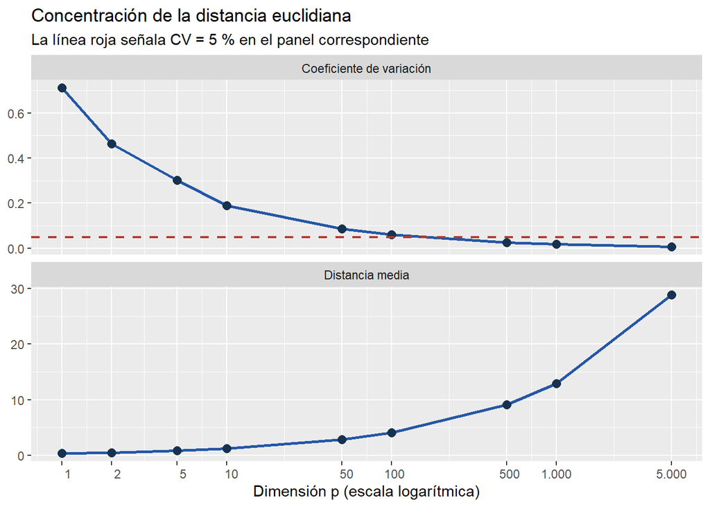

```r
ggplot(
  resultados_euclidiana_largo,
  aes(x = p, y = valor)
) +
  geom_line(linewidth = 0.9, color = "#2457a6") +
  geom_point(size = 2.6, color = "#16324f") +
  geom_hline(
    data = linea_umbral,
    aes(yintercept = umbral),
    inherit.aes = FALSE,
    linetype = "dashed",
    color = "#b03a2e",
    linewidth = 0.8
  ) +
  facet_wrap(vars(medida), scales = "free_y", ncol = 1) +
  scale_x_log10(
    breaks = p_valores,
    labels = format(p_valores, big.mark = ".", scientific = FALSE)
  ) +
  labs(
    title = "Concentración de la distancia euclidiana",
    subtitle = "La línea roja señala CV = 5 % en el panel correspondiente",
    x = "Dimensión p (escala logarítmica)",
    y = NULL
  )
```

**Respuesta 2.** La escala logarítmica en el eje $x$ permite visualizar en una misma figura dimensiones desde 1 hasta 5000. La distancia media crece, mientras que el coeficiente de variación converge hacia cero.

## 4.5 Umbral del 5 % e implicaciones para K-NN

```r
p_umbral_euclidiana <- resultados |>
  filter(is.finite(cv_euclidiana), cv_euclidiana < 0.05) |>
  summarise(p = if (n() == 0) NA_real_ else min(p)) |>
  pull(p)

if (is.na(p_umbral_euclidiana)) {
  texto_umbral_euclidiana <- paste(
    "En la cuadrícula evaluada, el CV euclidiano no cae por debajo del 5 %."
  )
} else {
  texto_umbral_euclidiana <- paste0(
    "El primer valor evaluado para el cual el CV euclidiano cae por debajo ",
    "del 5 % es p = ", p_umbral_euclidiana, "."
  )
}

texto_umbral_euclidiana
```

```
#> [1] "El primer valor evaluado para el cual el CV euclidiano cae por debajo del 5 % es p = 500."
```

**Respuesta 3.** El primer valor evaluado para el cual el CV euclidiano cae por debajo del 5 % es p = 500. Este resultado se refiere a los valores de $p$ incluidos en el ejercicio; el cruce exacto podría encontrarse entre dos valores consecutivos de la cuadrícula.

Para K-NN, la reducción del CV indica que las distancias se parecen cada vez más entre sí. Por tanto, disminuye el contraste relativo entre vecinos “cercanos” y “lejanos”, la selección de los vecinos puede volverse más sensible al ruido y se requiere una muestra mucho mayor para cubrir adecuadamente el espacio. Esta es una manifestación de la **maldición de la dimensionalidad**.

El fenómeno no implica que todas las distancias sean exactamente iguales. Significa que su dispersión relativa respecto de la media se reduce. En una aplicación real de K-NN conviene seleccionar variables relevantes, estandarizar las escalas y considerar reducción de dimensionalidad o métricas adaptadas al problema.

## 4.6 Distancia coseno

### 4.6.1 Resultados

```r
tabla_coseno <- resultados |>
  transmute(
    p,
    `Distancia media` = media_coseno,
    `Desviación estándar` = sd_coseno,
    `CV` = cv_coseno,
    `CV (%)` = 100 * cv_coseno
  )

kable(
  tabla_coseno,
  digits = c(0, 6, 6, 6, 2),
  align = c("r", "r", "r", "r", "r"),
  caption = "Resultados para la distancia coseno"
)
```

Resultados para la distancia coseno

| p | Distancia media | Desviación estándar | CV | CV (%) |
| --- | --- | --- | --- | --- |
| 1 | 0.000000 | 0.000000 | NA | NA |
| 2 | 0.153041 | 0.184052 | 1.202635 | 120.26 |
| 5 | 0.227682 | 0.143893 | 0.631990 | 63.20 |
| 10 | 0.242841 | 0.096713 | 0.398257 | 39.83 |
| 50 | 0.253639 | 0.047839 | 0.188611 | 18.86 |
| 100 | 0.246308 | 0.034056 | 0.138265 | 13.83 |
| 500 | 0.251250 | 0.014440 | 0.057473 | 5.75 |
| 1000 | 0.250870 | 0.010412 | 0.041505 | 4.15 |
| 5000 | 0.250271 | 0.003989 | 0.015940 | 1.59 |

**Caso $p=1$.** Como los valores simulados son no negativos, dos vectores unidimensionales de norma positiva tienen la misma dirección. Su similitud coseno es 1 y su distancia coseno es 0. En consecuencia, tanto la media como la desviación son cero y el CV queda indefinido (`NA`), porque requeriría dividir entre cero.

### 4.6.2 Comparación de la concentración

```r
comparacion_cv <- resultados |>
  select(p, cv_euclidiana, cv_coseno) |>
  rename(
    Euclidiana = cv_euclidiana,
    Coseno = cv_coseno
  ) |>
  pivot_longer(
    cols = -p,
    names_to = "metrica",
    values_to = "cv"
  )
```

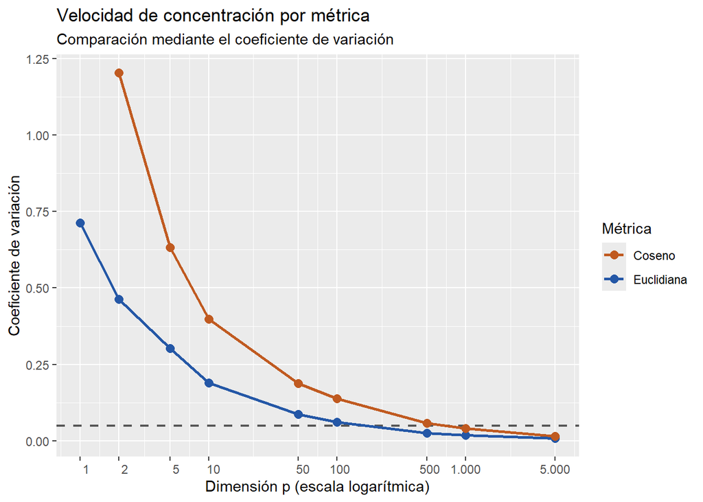

```r
ggplot(comparacion_cv, aes(x = p, y = cv, color = metrica)) +
  geom_hline(
    yintercept = 0.05,
    linetype = "dashed",
    color = "#555555",
    linewidth = 0.8
  ) +
  geom_line(linewidth = 0.9, na.rm = TRUE) +
  geom_point(size = 2.6, na.rm = TRUE) +
  scale_x_log10(
    breaks = p_valores,
    labels = format(p_valores, big.mark = ".", scientific = FALSE)
  ) +
  scale_color_manual(values = c(Euclidiana = "#2457a6", Coseno = "#c05a20")) +
  labs(
    title = "Velocidad de concentración por métrica",
    subtitle = "Comparación mediante el coeficiente de variación",
    x = "Dimensión p (escala logarítmica)",
    y = "Coeficiente de variación",
    color = "Métrica"
  )
```

### 4.6.3 Comparación de umbrales y tendencias

```r
p_umbral_coseno <- resultados |>
  filter(is.finite(cv_coseno), cv_coseno < 0.05) |>
  summarise(p = if (n() == 0) NA_real_ else min(p)) |>
  pull(p)

datos_pendiente_euclidiana <- resultados |>
  filter(p >= 5, is.finite(cv_euclidiana), cv_euclidiana > 0)

datos_pendiente_coseno <- resultados |>
  filter(p >= 5, is.finite(cv_coseno), cv_coseno > 0)

modelo_pendiente_euclidiana <- lm(
  log(cv_euclidiana) ~ log(p),
  data = datos_pendiente_euclidiana
)

modelo_pendiente_coseno <- lm(
  log(cv_coseno) ~ log(p),
  data = datos_pendiente_coseno
)

pendiente_euclidiana <- unname(coef(modelo_pendiente_euclidiana)[2])
pendiente_coseno <- unname(coef(modelo_pendiente_coseno)[2])

comparacion_umbral <- tibble(
  metrica = c("Euclidiana", "Coseno"),
  `Primer p con CV < 5 %` = c(p_umbral_euclidiana, p_umbral_coseno),
  `Pendiente log(CV) vs. log(p)` = c(
    pendiente_euclidiana,
    pendiente_coseno
  )
)

kable(
  comparacion_umbral,
  digits = c(0, 0, 4),
  align = c("l", "r", "r")
)
```

| metrica | Primer p con CV < 5 % | Pendiente log(CV) vs. log(p) |
| --- | --- | --- |
| Euclidiana | 500 | -0.5224 |
| Coseno | 1000 | -0.5200 |

**Respuesta 4.** En esta simulación, la distancia coseno alcanza un CV inferior al 5 % por primera vez en p = 1000. Según el umbral del 5 %, la distancia coseno se concentra después. Las pendientes estimadas en escala log–log son -0.522 para la distancia euclidiana y -0.52 para la distancia coseno.

Las dos métricas presentan concentración al aumentar $p$, pero no debe afirmarse que lo hacen exactamente a la misma velocidad: sus medias, dispersiones y umbrales pueden diferir. La conclusión se basa en el CV, el primer $p$ que cruza el 5 % y la pendiente de la curva, no solo en la apariencia del gráfico.

# 5 Ejercicio 5

## 5.1 Casos completos

Se convierten las variables explicativas a tipo numérico y se eliminan únicamente los registros incompletos en las seis variables requeridas.

```r
datos_modelo <- titanic |>
  transmute(
    across(
      all_of(predictores),
      ~ suppressWarnings(as.numeric(.x))
    ),
    survived = normalizar_supervivencia(.data$survived)
  ) |>
  drop_na()

if (!identical(sort(unique(datos_modelo$survived)), c(0L, 1L))) {
  stop("La variable survived debe contener las dos categorías 0 y 1.")
}

if (nrow(datos_modelo) < 3) {
  stop("No hay suficientes casos completos para ejecutar PCA y K-Means.")
}

resumen_casos <- tibble(
  concepto = c(
    "Filas originales",
    "Casos completos utilizados",
    "Filas excluidas"
  ),
  cantidad = c(
    nrow(titanic),
    nrow(datos_modelo),
    nrow(titanic) - nrow(datos_modelo)
  )
)

kable(resumen_casos, align = c("l", "r"))
```

| concepto | cantidad |
| --- | --- |
| Filas originales | 891 |
| Casos completos utilizados | 714 |
| Filas excluidas | 177 |

Se verifica que ningún predictor sea constante, porque una desviación estándar igual a cero impediría el escalamiento.

```r
desviaciones <- vapply(
  datos_modelo[predictores],
  sd,
  numeric(1)
)

desviaciones
```

```
#>        age       fare      sibsp      parch     pclass
#> 14.5264973 52.9189295  0.9297835  0.8532894  0.8382499
```

## 5.2 Análisis de componentes principales

### 5.2.1 Ajuste del PCA

`prcomp()` centra y escala cada variable antes de efectuar la descomposición. Esto es necesario porque `age`, `fare`, `sibsp`, `parch` y `pclass` se expresan en unidades y rangos distintos.

```r
X_sin_escalar <- datos_modelo |>
  select(all_of(predictores)) |>
  as.matrix()

pca <- prcomp(
  X_sin_escalar,
  center = TRUE,
  scale. = TRUE
)

# Matriz escalada utilizada por el PCA. También se empleará en K-Means.
X_escalada <- scale(
  X_sin_escalar,
  center = pca$center,
  scale = pca$scale
)

summary(pca)
```

```
#> Importance of components:
#>                           PC1    PC2    PC3    PC4     PC5
#> Standard deviation     1.3196 1.2703 0.8313 0.7680 0.60330
#> Proportion of Variance 0.3483 0.3227 0.1382 0.1180 0.07279
#> Cumulative Proportion  0.3483 0.6710 0.8092 0.9272 1.00000
```

### 5.2.2 Varianza explicada

```r
varianza <- pca$sdev^2
proporcion_varianza <- varianza / sum(varianza)
varianza_acumulada <- cumsum(proporcion_varianza)

tabla_varianza <- tibble(
  componente = seq_along(proporcion_varianza),
  nombre = paste0("PC", componente),
  valor_propio = varianza,
  proporcion = proporcion_varianza,
  acumulada = varianza_acumulada
)

n_80 <- which(varianza_acumulada >= 0.80)[1]
n_95 <- which(varianza_acumulada >= 0.95)[1]

kable(
  tabla_varianza,
  digits = c(0, 0, 5, 4, 4),
  align = c("r", "l", "r", "r", "r"),
  caption = "Varianza explicada por los componentes principales"
)
```

Varianza explicada por los componentes principales

| componente | nombre | valor_propio | proporcion | acumulada |
| --- | --- | --- | --- | --- |
| 1 | PC1 | 1.74136 | 0.3483 | 0.3483 |
| 2 | PC2 | 1.61366 | 0.3227 | 0.6710 |
| 3 | PC3 | 0.69112 | 0.1382 | 0.8092 |
| 4 | PC4 | 0.58989 | 0.1180 | 0.9272 |
| 5 | PC5 | 0.36397 | 0.0728 | 1.0000 |

**Respuesta 1.** Se necesitan **3 componentes** para retener al menos el 80 % de la varianza y **5 componentes** para retener al menos el 95 %. La selección se realiza con el primer componente cuya varianza acumulada alcanza cada umbral, por lo que no depende de redondeos visuales de la tabla.

## 5.3 *Scree plot* de varianza acumulada

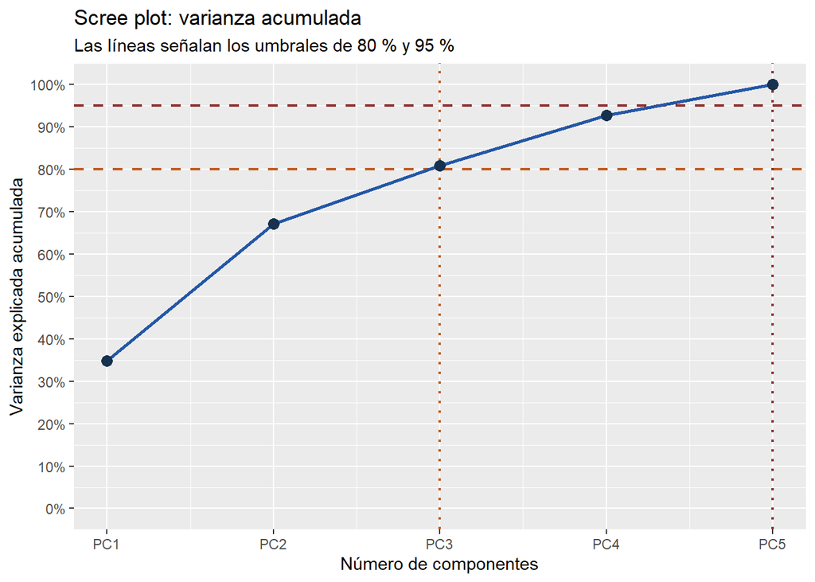

```r
ggplot(tabla_varianza, aes(x = componente, y = acumulada)) +
  geom_hline(
    yintercept = c(0.80, 0.95),
    linetype = "dashed",
    color = c("#c05a20", "#8e2f2f"),
    linewidth = 0.8
  ) +
  geom_vline(
    xintercept = c(n_80, n_95),
    linetype = "dotted",
    color = c("#c05a20", "#8e2f2f"),
    linewidth = 0.8
  ) +
  geom_line(color = "#2457a6", linewidth = 1) +
  geom_point(color = "#16324f", size = 3) +
  scale_x_continuous(
    breaks = tabla_varianza$componente,
    labels = tabla_varianza$nombre
  ) +
  scale_y_continuous(
    limits = c(0, 1),
    breaks = seq(0, 1, 0.1),
    labels = function(x) paste0(round(100 * x), "%")
  ) +
  labs(
    title = "Scree plot: varianza acumulada",
    subtitle = "Las líneas señalan los umbrales de 80 % y 95 %",
    x = "Número de componentes",
    y = "Varianza explicada acumulada"
  )
```

**Respuesta 2.** La curva siempre es creciente porque cada componente añade varianza explicada. Las líneas horizontales representan 80 % y 95 %, mientras que las líneas verticales identifican el primer número de componentes que alcanza cada umbral.

## 5.4 *Loadings* de PC1 y PC2

Los *loadings* son los coeficientes de las combinaciones lineales que definen cada componente. Una magnitud absoluta alta indica mayor contribución; el signo indica la dirección dentro del componente.

```r
loadings <- as.data.frame(pca$rotation[, 1:2, drop = FALSE]) |>
  rownames_to_column("variable") |>
  as_tibble() |>
  pivot_longer(
    cols = c(PC1, PC2),
    names_to = "componente",
    values_to = "carga"
  ) |>
  mutate(carga_absoluta = abs(carga))

kable(
  loadings |>
    select(variable, componente, carga, carga_absoluta),
  digits = 4,
  align = c("l", "l", "r", "r"),
  caption = "Loadings de los dos primeros componentes"
)
```

Loadings de los dos primeros componentes

| variable | componente | carga | carga_absoluta |
| --- | --- | --- | --- |
| age | PC1 | 0.5459 | 0.5459 |
| age | PC2 | -0.1972 | 0.1972 |
| fare | PC1 | 0.4201 | 0.4201 |
| fare | PC2 | 0.5267 | 0.5267 |
| sibsp | PC1 | -0.3115 | 0.3115 |
| sibsp | PC2 | 0.5399 | 0.5399 |
| parch | PC1 | -0.2058 | 0.2058 |
| parch | PC2 | 0.5630 | 0.5630 |
| pclass | PC1 | -0.6213 | 0.6213 |
| pclass | PC2 | -0.2743 | 0.2743 |

### 5.4.1 Variables dominantes

Se seleccionan las dos variables con mayor carga absoluta en cada componente.

```r
dominantes <- loadings |>
  group_by(componente) |>
  arrange(desc(carga_absoluta), .by_group = TRUE) |>
  slice_head(n = 2) |>
  ungroup()

kable(
  dominantes |>
    select(componente, variable, carga, carga_absoluta),
  digits = 4,
  align = c("l", "l", "r", "r"),
  caption = "Variables dominantes por componente"
)
```

Variables dominantes por componente

| componente | variable | carga | carga_absoluta |
| --- | --- | --- | --- |
| PC1 | pclass | -0.6213 | 0.6213 |
| PC1 | age | 0.5459 | 0.5459 |
| PC2 | parch | 0.5630 | 0.5630 |
| PC2 | sibsp | 0.5399 | 0.5399 |

**Respuesta 3.** Las variables con mayor carga absoluta en PC1 son pclass (-) y age (+); en PC2 son parch (+) y sibsp (+). La interpretación debe considerar conjuntamente magnitud y signo: variables con el mismo signo cambian en la misma dirección dentro del componente, mientras que signos opuestos representan un contraste.

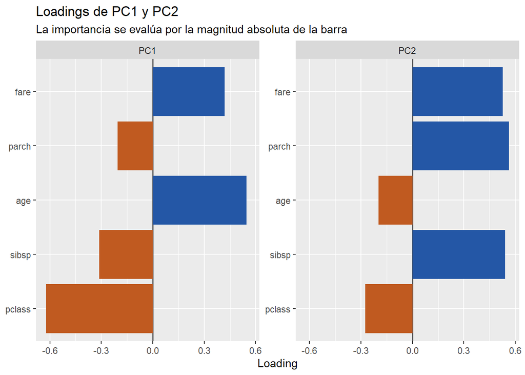

```r
ggplot(loadings, aes(x = reorder(variable, carga), y = carga, fill = carga > 0)) +
  geom_hline(yintercept = 0, color = "#555555", linewidth = 0.6) +
  geom_col(show.legend = FALSE) +
  coord_flip() +
  facet_wrap(vars(componente), scales = "free_y") +
  scale_fill_manual(values = c(`TRUE` = "#2457a6", `FALSE` = "#c05a20")) +
  labs(
    title = "Loadings de PC1 y PC2",
    subtitle = "La importancia se evalúa por la magnitud absoluta de la barra",
    x = NULL,
    y = "Loading"
  )
```

En el contexto del Titanic:

- `age` representa la edad del pasajero.
- `fare` aproxima el valor económico del tiquete.
- `sibsp` y `parch` reflejan acompañamiento familiar a bordo.
- `pclass` es ordinal: valores altos indican una clase de viaje más baja —tercera clase frente a primera—.

Por tanto, un componente dominado por `sibsp` y `parch` puede interpretarse como una dimensión de **acompañamiento o tamaño familiar**; uno dominado por `fare` y `pclass`, especialmente con signos opuestos, puede reflejar una dimensión de **posición socioeconómica o condiciones de viaje**; y una carga alta de `age` introduce una dimensión de **ciclo de vida**. La interpretación concreta debe ajustarse a los signos y magnitudes que aparecen en la tabla.

**Precauciones.** El signo completo de un componente puede invertirse sin cambiar el PCA; por ello importa el patrón relativo de signos, no que una carga sea positiva por sí misma. Además, `pclass` es ordinal y aquí se trata como numérica, una simplificación que debe reconocerse al interpretar distancias.

## 5.5 K-Means sobre dos representaciones

### 5.5.1 Funciones de evaluación

Las etiquetas 1 y 2 de K-Means son arbitrarias. Por esta razón se utiliza una exactitud con la mejor alineación posible de etiquetas y el índice Rand ajustado (ARI), que es invariante al nombre de los grupos y corrige el acuerdo esperado por azar.

```r
exactitud_binaria_optima <- function(cluster, verdad) {
  niveles_cluster <- sort(unique(cluster))

  if (length(niveles_cluster) != 2) {
    return(NA_real_)
  }

  prediccion <- as.integer(cluster == niveles_cluster[2])
  max(
    mean(prediccion == verdad),
    mean((1L - prediccion) == verdad)
  )
}

indice_rand_ajustado <- function(cluster, verdad) {
  tabla <- table(cluster, verdad)
  combinar_2 <- function(x) x * (x - 1) / 2

  suma_celdas <- sum(combinar_2(tabla))
  suma_filas <- sum(combinar_2(rowSums(tabla)))
  suma_columnas <- sum(combinar_2(colSums(tabla)))
  total_pares <- combinar_2(sum(tabla))

  esperado <- suma_filas * suma_columnas / total_pares
  maximo <- 0.5 * (suma_filas + suma_columnas)
  denominador <- maximo - esperado

  if (abs(denominador) < .Machine$double.eps) {
    return(NA_real_)
  }

  (suma_celdas - esperado) / denominador
}
```

### 5.5.2 Ajuste de los dos modelos

Para la matriz original se utiliza `X_escalada`, es decir, las cinco variables en la misma escala. Para la representación reducida se emplean directamente los puntajes de PC1 y PC2; no se vuelven a escalar, con el fin de conservar la varianza relativa que asigna el PCA.

```r
set.seed(42)
kmeans_X <- kmeans(
  X_escalada,
  centers = 2,
  nstart = 50,
  iter.max = 100
)

puntajes_PC12 <- pca$x[, 1:2, drop = FALSE]

set.seed(42)
kmeans_PC12 <- kmeans(
  puntajes_PC12,
  centers = 2,
  nstart = 50,
  iter.max = 100
)

supervivencia <- datos_modelo$survived
```

### 5.5.3 Tablas de contingencia

```r
tabla_X <- table(
  Cluster = kmeans_X$cluster,
  Survived = supervivencia
)

tabla_PC12 <- table(
  Cluster = kmeans_PC12$cluster,
  Survived = supervivencia
)

kable(
  addmargins(tabla_X),
  caption = "K-Means sobre X escalada frente a survived"
)
```

K-Means sobre X escalada frente a survived

|  | 0 | 1 | Sum |
| --- | --- | --- | --- |
| 1 | 85 | 133 | 218 |
| 2 | 339 | 157 | 496 |
| Sum | 424 | 290 | 714 |

```r
kable(
  addmargins(tabla_PC12),
  caption = "K-Means sobre PC1 y PC2 frente a survived"
)
```

K-Means sobre PC1 y PC2 frente a survived

|  | 0 | 1 | Sum |
| --- | --- | --- | --- |
| 1 | 81 | 131 | 212 |
| 2 | 343 | 159 | 502 |
| Sum | 424 | 290 | 714 |

### 5.5.4 Métricas de coincidencia

```r
resumen_kmeans <- tibble(
  representacion = c("X escalada (5 variables)", "PC1 y PC2"),
  exactitud_alineada = c(
    exactitud_binaria_optima(kmeans_X$cluster, supervivencia),
    exactitud_binaria_optima(kmeans_PC12$cluster, supervivencia)
  ),
  ari = c(
    indice_rand_ajustado(kmeans_X$cluster, supervivencia),
    indice_rand_ajustado(kmeans_PC12$cluster, supervivencia)
  ),
  suma_cuadrados_intra = c(
    kmeans_X$tot.withinss,
    kmeans_PC12$tot.withinss
  )
)

kable(
  resumen_kmeans,
  digits = c(0, 4, 4, 3),
  align = c("l", "r", "r", "r"),
  caption = "Comparación de los agrupamientos con la supervivencia"
)
```

Comparación de los agrupamientos con la supervivencia

| representacion | exactitud_alineada | ari | suma_cuadrados_intra |
| --- | --- | --- | --- |
| X escalada (5 variables) | 0.6611 | 0.0979 | 2659.107 |
| PC1 y PC2 | 0.6639 | 0.1012 | 1504.460 |

**Respuesta 4.** De acuerdo con el mayor índice Rand ajustado, la representación que coincide mejor con `survived` es **los dos primeros componentes**. La conclusión es empírica y corresponde a los casos completos del archivo analizado.

### 5.5.5 Visualización de la composición de los grupos

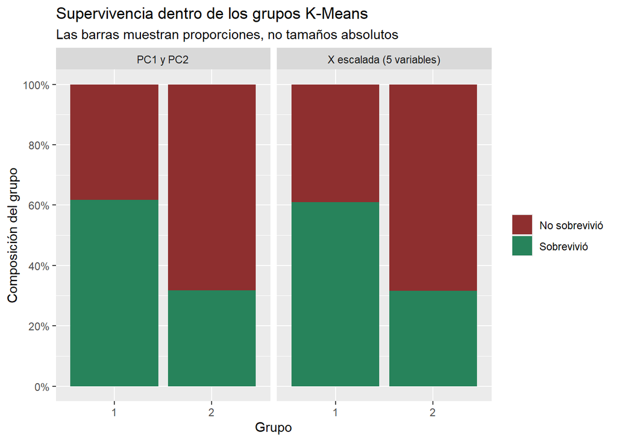

```r
datos_clusters <- tibble(
  survived = factor(
    supervivencia,
    levels = c(0, 1),
    labels = c("No sobrevivió", "Sobrevivió")
  ),
  `X escalada (5 variables)` = factor(kmeans_X$cluster),
  `PC1 y PC2` = factor(kmeans_PC12$cluster)
) |>
  pivot_longer(
    cols = -survived,
    names_to = "representacion",
    values_to = "cluster"
  )

ggplot(datos_clusters, aes(x = cluster, fill = survived)) +
  geom_bar(position = "fill") +
  facet_wrap(vars(representacion)) +
  scale_y_continuous(
    breaks = seq(0, 1, 0.2),
    labels = function(x) paste0(round(100 * x), "%")
  ) +
  scale_fill_manual(values = c("#8e2f2f", "#27835b")) +
  labs(
    title = "Supervivencia dentro de los grupos K-Means",
    subtitle = "Las barras muestran proporciones, no tamaños absolutos",
    x = "Grupo",
    y = "Composición del grupo",
    fill = NULL
  )
```

### 5.5.6 Puntajes de los dos primeros componentes

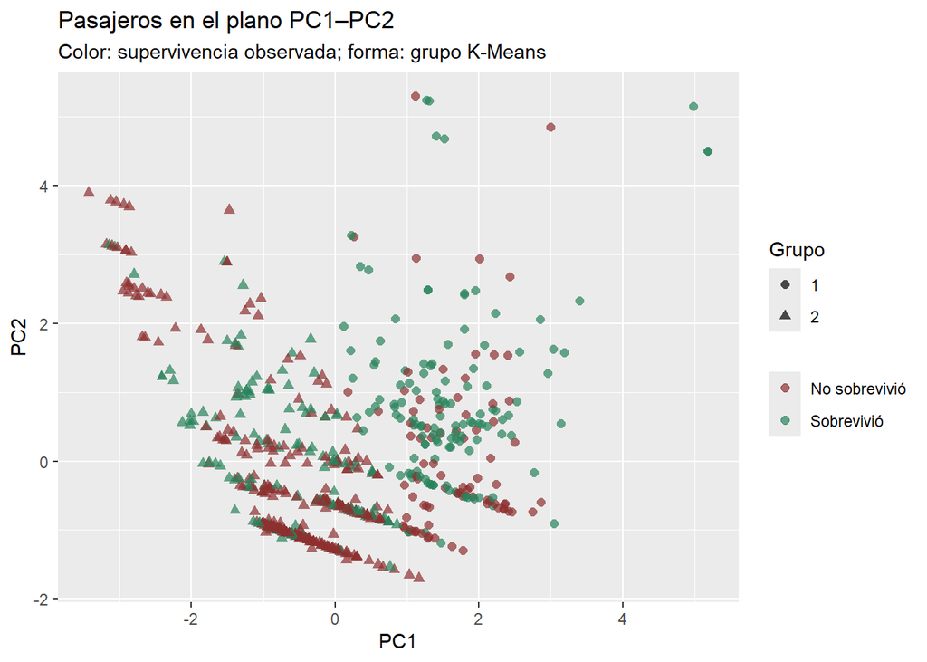

```r
datos_puntajes <- tibble(
  PC1 = pca$x[, 1],
  PC2 = pca$x[, 2],
  survived = factor(
    supervivencia,
    levels = c(0, 1),
    labels = c("No sobrevivió", "Sobrevivió")
  ),
  cluster = factor(kmeans_PC12$cluster)
)

ggplot(datos_puntajes, aes(x = PC1, y = PC2, color = survived, shape = cluster)) +
  geom_point(alpha = 0.7, size = 2) +
  scale_color_manual(values = c("#8e2f2f", "#27835b")) +
  labs(
    title = "Pasajeros en el plano PC1–PC2",
    subtitle = "Color: supervivencia observada; forma: grupo K-Means",
    x = "PC1",
    y = "PC2",
    color = NULL,
    shape = "Grupo"
  )
```

**Alcance de la comparación.** K-Means es un método no supervisado: busca grupos compactos, no maximiza la predicción de `survived`. Una coincidencia baja no implica que el algoritmo esté mal ejecutado; indica que la geometría de estas cinco variables no reproduce de manera directa la clasificación de supervivencia. Además, agrupar sobre los cinco componentes sería equivalente a agrupar sobre `X_escalada`, porque el PCA completo es una rotación ortogonal. Las diferencias aparecen aquí porque la segunda alternativa conserva solo PC1 y PC2.